# Exercise 7 — Bayesian Disease Mapping with R-INLA

BSTA 374 · Optional, extra credit: 10 points · Due Friday, November 13, 2026, 11:59 pm

Author

Maggie Sobaszek · Lehigh University

Published

November 13, 2026

## What this exercise is

This exercise is **optional, for extra credit: up to 10 points**.

In Exercises 4 to 6 you mapped the **SMR** of 2020 COVID-19 deaths in Pennsylvania. Small counties had extreme SMRs that rested on very few deaths. Here you replace each SMR with a Bayesian **posterior**: a curve that says which values of the risk are plausible. From each curve we read two things:

- the **best guess**, the centre of the curve;
- the **95% credible interval**, the range that holds the middle 95% of the curve: the true risk lies in it with 95% probability.

You start from the SMR map, then build the posterior by hand, then with R-INLA for all 67 counties.

All the code is provided, and you do not need to change any of it. Run the chunks from top to bottom with the green arrow at the top right of each chunk, and **look at the figures**. Most questions ask you to read a number off a figure or a table, or need one or two sentences; one asks you to compute a credible interval by hand, with a calculator.

| Part | What you look at | Points |
| --- | --- | --- |
| A | The SMR map, and how unstable it is in small counties | 1 |
| B | Posterior and credible interval, by hand | 3 |
| C | INLA does the same for all 67 counties (no question) | — |
| D | INLA’s posteriors and credible intervals | 3 |
| E | Borrowing from the neighbours | 1 |
| F | Where is the risk clearly higher? | 1 |
| G | Wrapping up | 1 |

**ImportantBefore you start**

1. Install **INLA** once. It is not on CRAN, so run this in the RStudio **Console** (it takes a few minutes):

   ```r
   install.packages("INLA",
     repos = c(getOption("repos"), INLA = "https://inla.r-inla-download.org/R/stable"))
   ```

   Check it with `library(INLA)`. If INLA will not install on your laptop, use a computer lab machine or [Posit Cloud](https://posit.cloud), and email me.
2. Save this file as `LASTNAME_FI_Exercise7.qmd`, next to the `data/` folder that holds `pa_covid_deaths_2020.csv` (as in Exercises 4–6).

**ImportantSubmission**

Choose **either** option; both earn the same credit.

- **Option 1:** upload `LASTNAME_FI_Exercise7.qmd`, with your answers typed in, to Course Site. No rendering needed.
- **Option 2:** render the page, publish it to GitHub Pages as for Exercise 4, and submit the `.qmd` and the page URL.

**TipIf something does not run**

Restart R (*Session > Restart R*) and run the chunks from the top, in order. If `inla()` still stops with an error, email me the exact message — or answer the questions you can; partial answers earn partial credit.

## Part A — The SMR map (1 point)

The first steps of Exercises 4 to 6: the join, the expected deaths and the SMR. Run this chunk first.

```r
library(sf)
library(dplyr)
library(tidyr)
library(readr)
library(ggplot2)
library(patchwork)
library(spdep)
library(INLA)
library(tigris)
options(tigris_use_cache = TRUE)

covid <- read_csv("data/pa_covid_deaths_2020.csv", show_col_types = FALSE) |>
  mutate(GEOID = sprintf("%05d", as.integer(FIPS)))      # text key, as in Ex. 4
pa <- counties(state = "PA", cb = TRUE, year = 2020, progress_bar = FALSE)

pa_covid <- pa |>
  left_join(covid, by = "GEOID") |>
  st_transform(5070) |>
  arrange(GEOID)

r <- sum(pa_covid$deaths_2020) / sum(pa_covid$Population)   # state rate
pa_covid <- pa_covid |>
  mutate(O   = deaths_2020,                                 # observed deaths
         E   = r * Population,                              # expected deaths
         SMR = O / E)

# the SMR classes and colours of Exercise 4
smr_breaks <- c(0, 0.5, 2/3, 0.9, 1/0.9, 1.5, 2, Inf)
smr_labels <- c("< 0.50", "0.50-0.67", "0.67-0.90", "0.90-1.11",
                "1.11-1.50", "1.50-2.00", "> 2.00")
smr_fill   <- scale_fill_brewer(palette = "RdBu", direction = -1, drop = FALSE,
                                name = NULL)
```

Now map the SMR, with the classes and colours of Exercise 4. The three least populated counties are outlined and labelled.

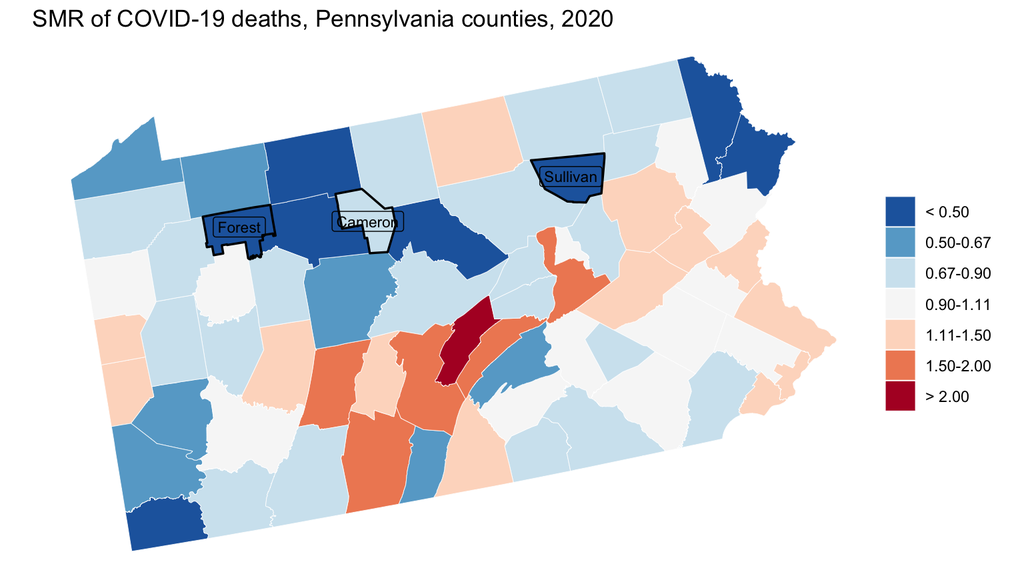

```r
tiny <- filter(pa_covid, NAME %in% c("Cameron", "Sullivan", "Forest"))   # fewest people

ggplot(pa_covid) +
  geom_sf(aes(fill = cut(SMR, smr_breaks, smr_labels)), colour = "white",
          linewidth = 0.15) +
  geom_sf(data = tiny, fill = NA, colour = "black", linewidth = 0.6) +   # outline
  geom_sf_label(data = tiny, aes(label = NAME), size = 3) +
  smr_fill +
  labs(title = "SMR of COVID-19 deaths, Pennsylvania counties, 2020") +
  theme_void()
```

How much would **one more death** change the SMR? The three least populated counties, and the three most populated:

```r
six <- pa_covid |>
  st_drop_geometry() |>
  arrange(E) |>
  slice(c(1:3, 65:67)) |>                            # 3 smallest, 3 largest
  mutate(SMR_one_more = (O + 1) / E)                 # with one more death

six |>
  select(NAME, Population, O, E, SMR, SMR_one_more) |>
  knitr::kable(digits = 2, format.args = list(big.mark = ","))
```

| NAME | Population | O | E | SMR | SMR_one_more |
| --- | --- | --- | --- | --- | --- |
| Cameron | 4,447 | 4 | 5.57 | 0.72 | 0.90 |
| Sullivan | 6,066 | 3 | 7.60 | 0.39 | 0.53 |
| Forest | 7,247 | 3 | 9.07 | 0.33 | 0.44 |
| Montgomery | 830,915 | 1,147 | 1,040.43 | 1.10 | 1.10 |
| Allegheny | 1,216,045 | 1,009 | 1,522.67 | 0.66 | 0.66 |
| Philadelphia | 1,584,064 | 2,450 | 1,983.48 | 1.24 | 1.24 |

**A1.** On the map, what colour is Forest County, and what is its SMR? In the table, how much would its SMR change with just one more death? And Philadelphia’s? What does this say about the colours of small counties on the map?

**Forest county is dark blue with an SMR of 0.33, but an SMR of 0.44 with just one more death. Philadelphia’s SMR is 1.24 and with one more death is still the same. The small counties are unstable, because their populations are so small.**

## Part B — Posterior and credible interval, by hand (3 points)

In class, every restaurant borrowed 10 ratings from the area, and the family’s well borrowed 10 tests from nearby wells. We do the same for counties: each county **borrows 20 expected deaths from the state, at the state rate** (SMR = 1). Its best guess is then

$$\text{best guess} \;=\; w \times \text{SMR} + (1 - w) \times 1,
\qquad w = \frac{E}{E + 20},$$

where $w$ is how much we trust the county’s own SMR, between 0 and 1.

We look at three counties: **Cameron** and **Forest**, two of the three least populated counties of Pennsylvania, where almost nobody lives, and **Philadelphia**, the most populated.

```r
three <- pa_covid |>
  st_drop_geometry() |>
  filter(NAME %in% c("Cameron", "Forest", "Philadelphia")) |>
  mutate(w          = E / (E + 20),                          # trust in own SMR
         best_guess = (20 + O) / (20 + E),                   # 20 borrowed deaths
         CI_low     = qgamma(0.025, 20 + O, 20 + E),         # 95% credible interval
         CI_high    = qgamma(0.975, 20 + O, 20 + E)) |>
  arrange(E)

three |>
  select(NAME, Population, O, E, SMR, w, best_guess, CI_low, CI_high) |>
  knitr::kable(digits = 2, format.args = list(big.mark = ","))
```

| NAME | Population | O | E | SMR | w | best_guess | CI_low | CI_high |
| --- | --- | --- | --- | --- | --- | --- | --- | --- |
| Cameron | 4,447 | 4 | 5.57 | 0.72 | 0.22 | 0.94 | 0.60 | 1.35 |
| Forest | 7,247 | 3 | 9.07 | 0.33 | 0.31 | 0.79 | 0.50 | 1.15 |
| Philadelphia | 1,584,064 | 2,450 | 1,983.48 | 1.24 | 0.99 | 1.23 | 1.18 | 1.28 |

The same thing as a picture. Red dotted: the **prior** (the 20 borrowed deaths). Blue: the county’s own **data**. Green: the **posterior**, the two combined. The green shaded area is the **95% credible interval**, and the green dashed line the **best guess**.

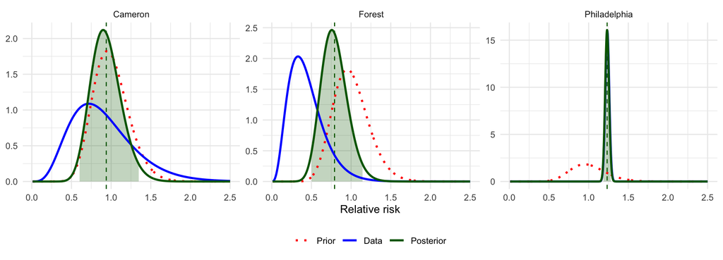

```r
curves <- function(name, k = 20) {
  x <- pa_covid[pa_covid$NAME == name, ]
  tibble(theta     = seq(0.01, 2.5, by = 0.002),
         Prior     = dgamma(theta, k, k),                  # 20 borrowed deaths
         Data      = dgamma(theta, x$O + 1, x$E),          # own deaths only
         Posterior = dgamma(theta, k + x$O, k + x$E),      # both together
         county    = name)
}

cur <- bind_rows(lapply(three$NAME, curves)) |>
  pivot_longer(c(Prior, Data, Posterior), names_to = "curve", values_to = "density") |>
  mutate(curve = factor(curve, c("Prior", "Data", "Posterior")))
shade <- cur |>
  filter(curve == "Posterior") |>
  left_join(select(three, county = NAME, CI_low, CI_high), by = "county") |>
  filter(theta >= CI_low, theta <= CI_high)                # middle 95%

ggplot(cur, aes(theta, density)) +
  geom_area(data = shade, fill = "darkgreen", alpha = 0.25) +           # credible interval
  geom_vline(data = rename(three, county = NAME), aes(xintercept = best_guess),
             colour = "darkgreen", linetype = 2) +                     # best guess
  geom_line(aes(colour = curve, linetype = curve), linewidth = 1) +
  facet_wrap(~ factor(county, three$NAME), scales = "free_y") +        # small to large
  scale_colour_manual(values = c(Prior = "red", Data = "blue", Posterior = "darkgreen")) +
  scale_linetype_manual(values = c(Prior = 3, Data = 1, Posterior = 1)) +
  labs(x = "Relative risk", y = NULL, colour = NULL, linetype = NULL) +
  theme_minimal() +
  theme(legend.position = "bottom")
```

**B1.** For which counties does the green curve sit close to the red prior, and for which close to the blue data? Which credible intervals are the widest? Use $w$ to explain why. **The posterior for Cameron and Forest counties are close to the prior because they are small counties where there is more shrinkage that happens because there’s less weight on their own data. For Philadelphia, much more weight is on their own data, so in the graph their data is almost exactly the same as the posterior. Cameron and Forest have the widest credible intervals, because less of their posterior comes from their own numbers. For Cameron, only 22% and Forest, 31% of the posterior is from their own data.**

### How to compute the credible interval by hand

The posterior is a curve whose total area is 1. The 95% credible interval **cuts 2.5% of the area off each side** and keeps the middle 95%. Here the posterior curve is set by two numbers:

$$a = 20 + O \;\;\text{(borrowed + own deaths)}, \qquad
b = 20 + E \;\;\text{(borrowed + own expected deaths)}.$$

With a calculator, four steps give the interval:

| Step | Formula |
| --- | --- |
| 1. best guess | $a / b$ |
| 2. spread (standard deviation) | $\sqrt{a} \,/\, b$ |
| 3. low end | best guess $- \, 1.96 \times$ spread |
| 4. high end | best guess $+ \, 1.96 \times$ spread |

This is the familiar “estimate $\pm$ 1.96 standard errors”, applied to the posterior. It is an approximation: R’s `qgamma()` cuts the 2.5% tails of the curve itself, which gives the exact interval of the table. Both, for Forest:

```r
fo     <- filter(three, NAME == "Forest")
a      <- 20 + fo$O                                  # borrowed + own deaths
b      <- 20 + fo$E                                  # borrowed + own expected
best   <- a / b                                      # step 1
spread <- sqrt(a) / b                                # step 2
round(c(a = a, b = b, best_guess = best, spread = spread), 2)
```

```
         a          b best_guess     spread
     23.00      29.07       0.79       0.16
```

```r
round(best + c(-1.96, 1.96) * spread, 2)             # steps 3-4: by hand
```

```
[1] 0.47 1.11
```

```r
round(qgamma(c(0.025, 0.975), a, b), 2)              # exact: cut 2.5% each side
```

```
[1] 0.50 1.15
```

The same two intervals on Forest’s posterior curve. Grey: the 2.5% cut off on each side. Green: the middle 95%, the exact interval. Black bar below: the interval by hand.

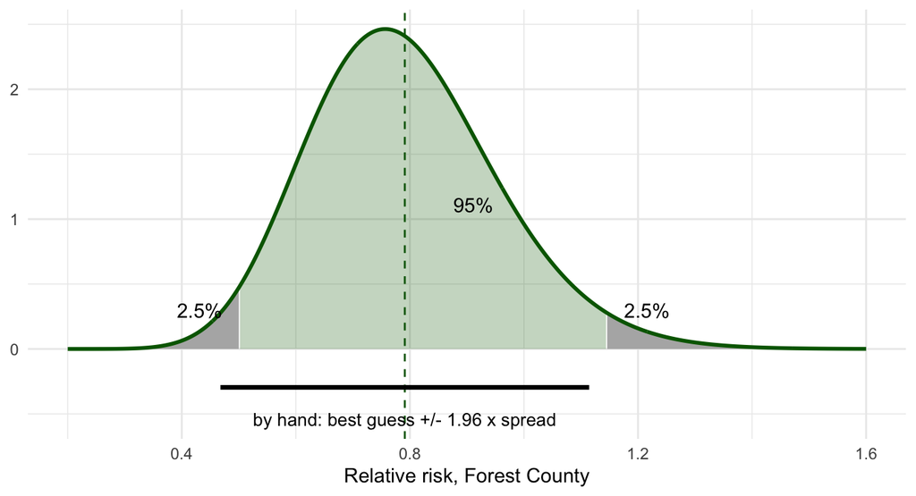

```r
ex   <- qgamma(c(0.025, 0.975), a, b)                # exact interval
hand <- best + c(-1.96, 1.96) * spread               # by hand
d    <- tibble(x = seq(0.2, 1.6, by = 0.002), y = dgamma(x, a, b))
top  <- max(d$y)

ggplot(d, aes(x, y)) +
  geom_area(data = filter(d, x <= ex[1]), fill = "grey70") +                # lower 2.5%
  geom_area(data = filter(d, x >= ex[2]), fill = "grey70") +                # upper 2.5%
  geom_area(data = filter(d, x >= ex[1], x <= ex[2]), fill = "darkgreen", alpha = 0.25) +
  geom_line(colour = "darkgreen", linewidth = 1) +
  geom_vline(xintercept = best, colour = "darkgreen", linetype = 2) +        # best guess
  annotate("text", x = c(ex[1] - 0.07, best + 0.12, ex[2] + 0.07),
           y = top * c(0.12, 0.45, 0.12), label = c("2.5%", "95%", "2.5%")) +
  annotate("segment", x = hand[1], xend = hand[2], y = -0.12 * top,
           yend = -0.12 * top, linewidth = 1.2) +                           # by hand
  annotate("text", x = best, y = -0.22 * top, size = 3.5,
           label = "by hand: best guess +/- 1.96 x spread") +
  labs(x = "Relative risk, Forest County", y = NULL) +
  theme_minimal()
```

```r
fo     <- filter(three, NAME == "Cameron")
a      <- 20 + fo$O                                  # borrowed + own deaths
b      <- 20 + fo$E                                  # borrowed + own expected
best   <- a / b                                      # step 1
spread <- sqrt(a) / b                                # step 2
round(c(a = a, b = b, best_guess = best, spread = spread), 2)
```

```
         a          b best_guess     spread
     24.00      25.57       0.94       0.19
```

```r
round(best + c(-1.96, 1.96) * spread, 2)             # steps 3-4: by hand
```

```
[1] 0.56 1.31
```

```r
round(qgamma(c(0.025, 0.975), a, b), 2)              # exact: cut 2.5% each side
```

```
[1] 0.60 1.35
```

**B2.** Your turn, for **Cameron**, with a calculator (its $O$ and $E$ are in the table): $a$ = **24.0**, $b$ = **25.57**, best guess = **0.94**, spread = **0.19**, 95% credible interval by hand from **0.56** to **1.31**. Is it close to the exact interval (`CI_low` to `CI_high`) in the table? **It is close to the exact interval in the table.**

## Part C — INLA does the same for all 67 counties (no question)

In Part B, **you** chose to borrow 20 deaths, and every county borrowed from the **state**. INLA keeps the idea and changes two things:

1. the **data decide** how much each county borrows;
2. each county borrows mostly from its **neighbours**, as the well borrowed from nearby wells. This is the **BYM2** model (Moraga §5.3).

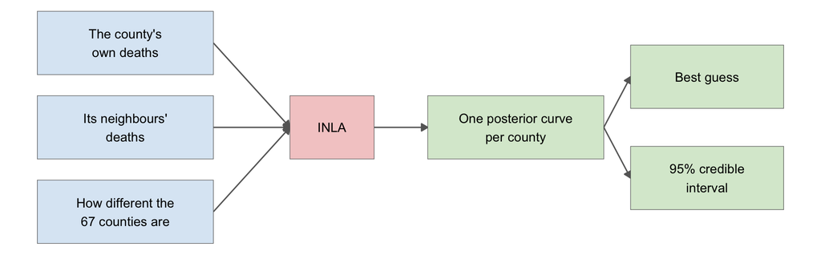

The INLA code is the one chunk worth reading:

| Piece of the code | In words |
| --- | --- |
| `O ~ 1` | model the observed deaths around one overall level of risk |
| `f(id, model = "bym2", graph = g)` | each county gets its own risk, pulled toward its neighbours (listed in `g`) |
| `family = "poisson", E = E` | deaths are counts, compared with expected deaths, so results read like an SMR |
| `control...` | only asks INLA to keep the results we need |

```r
nb <- poly2nb(pa_covid, queen = TRUE)                # queen neighbours
nb2INLA("pa.adj", nb)                                # write them for INLA
g  <- inla.read.graph("pa.adj")

dat <- st_drop_geometry(pa_covid) |>
  mutate(id = row_number())                          # one index per county

m <- inla(O ~ 1 + f(id, model = "bym2", graph = g),  # borrow from neighbours
          family = "poisson", E = E, data = dat,     # deaths vs expected deaths
          control.predictor = list(compute = TRUE),
          control.compute   = list(return.marginals.predictor = TRUE))

res <- m$summary.fitted.values                       # one row per county
pa_covid$RR <- res$mean                              # best guess
pa_covid$LL <- res$`0.025quant`                      # 95% credible interval, low
pa_covid$UL <- res$`0.975quant`                      # 95% credible interval, high
```

The raw SMR and INLA’s best guess, with the colours of Exercise 4:

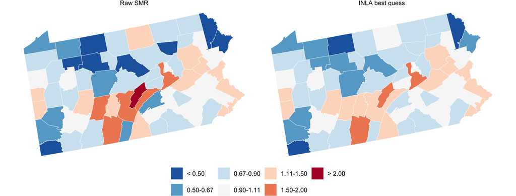

```r
pa_covid |>
  select(SMR, RR) |>
  pivot_longer(c(SMR, RR), names_to = "map", values_to = "value") |>
  mutate(map   = factor(map, c("SMR", "RR"), c("Raw SMR", "INLA best guess")),
         class = cut(value, smr_breaks, smr_labels)) |>
  ggplot() +
  geom_sf(aes(fill = class), colour = "white", linewidth = 0.15) +
  facet_wrap(~ map) +
  smr_fill +
  theme_void() +
  theme(legend.position = "bottom")
```

## Part D — INLA’s posteriors and credible intervals (3 points)

### Two counties, two posterior curves

Montour and Montgomery have the **same raw SMR**. Here are INLA’s posterior curves for both, on the same horizontal axis. Green shaded: the 95% credible interval. Green dashed: the best guess. Black: the state average, 1.

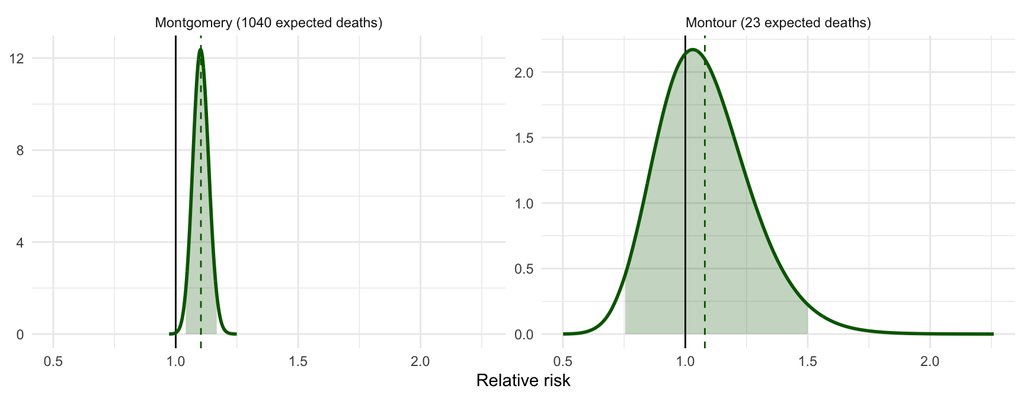

```r
post_curve <- function(name) {
  i  <- which(pa_covid$NAME == name)
  cv <- inla.smarginal(m$marginals.fitted.values[[i]])   # INLA's curve
  data.frame(county = paste0(name, " (", round(pa_covid$E[i]), " expected deaths)"),
             x = cv$x, y = cv$y,
             RR = pa_covid$RR[i], LL = pa_covid$LL[i], UL = pa_covid$UL[i])
}

cur <- bind_rows(post_curve("Montour"), post_curve("Montgomery"))

ggplot(cur, aes(x, y)) +
  geom_area(data = filter(cur, x >= LL, x <= UL), fill = "darkgreen", alpha = 0.25) +
  geom_vline(aes(xintercept = RR), colour = "darkgreen", linetype = 2) +   # best guess
  geom_vline(xintercept = 1) +                                           # state average
  geom_line(colour = "darkgreen", linewidth = 1) +
  facet_wrap(~ county, scales = "free_y") +
  labs(x = "Relative risk", y = NULL) +
  theme_minimal()
```

```r
pa_covid |>
  st_drop_geometry() |>
  filter(NAME %in% c("Montour", "Montgomery")) |>
  select(NAME, O, E, SMR, RR, LL, UL) |>
  knitr::kable(digits = 2)
```

| NAME | O | E | SMR | RR | LL | UL |
| --- | --- | --- | --- | --- | --- | --- |
| Montgomery | 1147 | 1040.43 | 1.1 | 1.10 | 1.04 | 1.17 |
| Montour | 25 | 22.83 | 1.1 | 1.08 | 0.75 | 1.50 |

**D1.** Fill in, from the table: Montour’s best guess is **1.08**, with a 95% credible interval from **0.75 to 1.50**. Montgomery’s best guess is **1.10**, from **1.04 to 1.17**.

**D2.** Which interval contains 1, the state average? What does that mean for that county, and why is its interval so much wider? **Montour’s interval, between 0.75 and 1.50, contains 1 and which means that it includes the state average, and so the relative risk for Montour could be the same as the state average. It has a much wider interval because it has less observed deaths compared to Montgomery.**

### All 67 counties

Each row is one county’s posterior curve seen from above: the bar is its 95% credible interval, the dot its best guess, and the × its raw SMR. Small counties are at the top. Red: the whole interval is above 1. Blue: the whole interval is below 1. Grey: the interval contains 1.

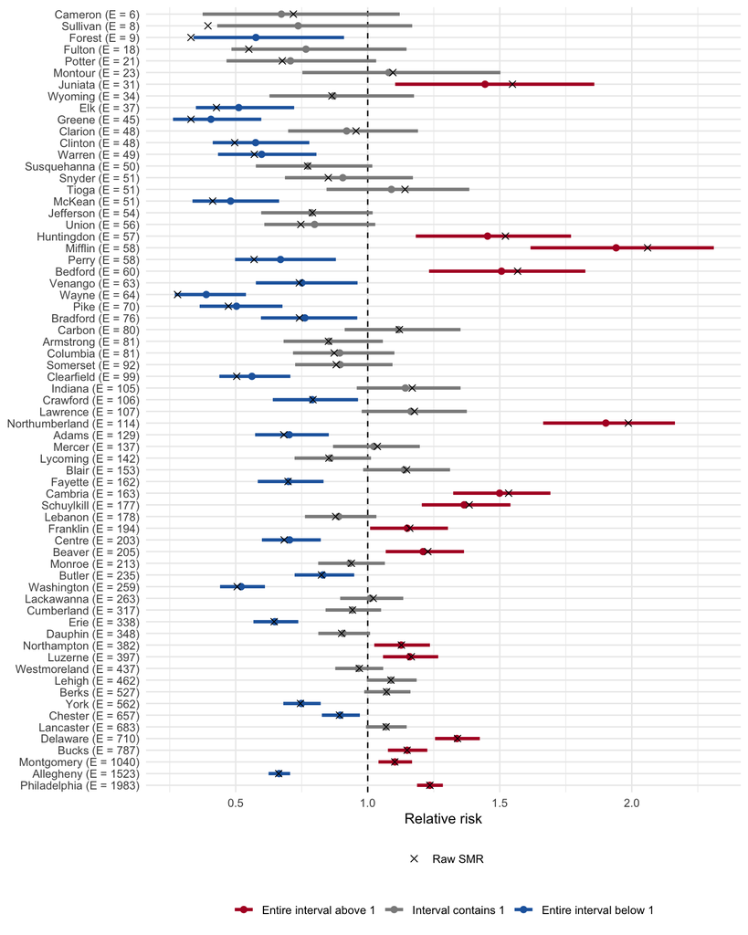

```r
ci_cols <- c("Entire interval above 1" = "#B2182B",
             "Interval contains 1"     = "grey55",
             "Entire interval below 1" = "#2166AC")

pa_covid <- pa_covid |>
  mutate(ci_class = factor(case_when(LL > 1 ~ names(ci_cols)[1],
                                     UL < 1 ~ names(ci_cols)[3],
                                     TRUE   ~ names(ci_cols)[2]), names(ci_cols)))

pa_covid |>
  st_drop_geometry() |>
  mutate(county = reorder(paste0(NAME, " (E = ", round(E), ")"), -E)) |>   # small on top
  ggplot(aes(y = county)) +
  geom_vline(xintercept = 1, linetype = 2) +                               # state average
  geom_linerange(aes(xmin = LL, xmax = UL, colour = ci_class), linewidth = 1.2) +
  geom_point(aes(x = RR, colour = ci_class), size = 2) +
  geom_point(aes(x = SMR, shape = "Raw SMR"), size = 2) +
  scale_colour_manual(values = ci_cols, drop = FALSE, name = NULL) +
  scale_shape_manual(values = c("Raw SMR" = 4), name = NULL) +
  labs(x = "Relative risk", y = NULL) +
  theme_minimal() +
  theme(legend.position = "bottom", legend.box = "vertical")
```

**D3.** Compare the small counties at the top with the large counties at the bottom. Whose bars are longer? Where are the counties whose dot moved far from its ×? Why? **The smaller counties at the top have longer bars because there’s fewer deaths, so there’s more uncertainty. Counties like Sullivan and Forest, where the dot is moved far from the x because there is shrinkage and their estimates are being pulled more toward the average because there’s less original data from the counties. In large counties like Philadelphia and Allegheny, have more certainty in their estimates.**

## Part E — Borrowing from the neighbours (1 point)

Cameron, outlined in black, and its neighbours. Left: their raw SMRs. Right: where INLA puts Cameron, with its 95% credible interval, compared with its own SMR, its neighbours and the state average.

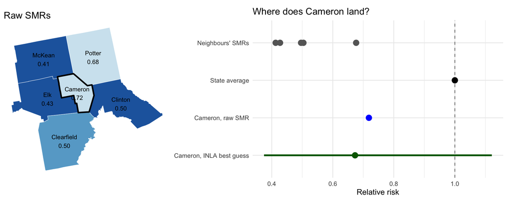

```r
i    <- which(pa_covid$NAME == "Cameron")
hood <- pa_covid[c(i, nb[[i]]), ]                    # Cameron, then its neighbours

p_map <- ggplot(hood) +
  geom_sf(aes(fill = cut(SMR, smr_breaks, smr_labels)), colour = "white") +
  geom_sf(data = hood[1, ], fill = NA, colour = "black", linewidth = 1) +   # Cameron
  geom_sf_text(aes(label = paste0(NAME, "\n", sprintf("%.2f", SMR))), size = 3) +
  smr_fill +
  labs(title = "Raw SMRs") +
  theme_void() +
  theme(legend.position = "none")

rows <- c("Neighbours' SMRs", "State average", "Cameron, raw SMR",
          "Cameron, INLA best guess")
pts <- tibble(what  = factor(c(rep(rows[1], nrow(hood) - 1), rows[2:4]), rev(rows)),
              value = c(hood$SMR[-1], 1, hood$SMR[1], hood$RR[1]))
bar <- tibble(what = factor(rows[4], rev(rows)), lo = hood$LL[1], hi = hood$UL[1])

p_line <- ggplot(pts, aes(value, what, colour = what)) +
  geom_vline(xintercept = 1, linetype = 2, colour = "grey50") +
  geom_linerange(data = bar, aes(xmin = lo, xmax = hi, y = what), inherit.aes = FALSE,
                 colour = "darkgreen", linewidth = 1.2) +                    # credible interval
  geom_point(size = 3.5) +
  scale_colour_manual(values = c("grey40", "black", "blue", "darkgreen"),
                      breaks = rows, guide = "none") +
  labs(title = "Where does Cameron land?", x = "Relative risk", y = NULL) +
  theme_minimal()

p_map + p_line
```

**E1.** In Part B, borrowing from the state pulled Cameron **up**, toward 1. Where does INLA put it, and why?

**The INLA best guess for Cameron is 0.67, where it is originally at 0.72. Borrowing from the state pulled it up, but INLA borrows from the SMR of the county’s neighbors, and theirs are all lower than Cameron’s SMR, so it pulled the SMR down.**

## Part F — Where is the risk clearly higher? (1 point)

The colours of the plot above, on the map: red counties have their whole 95% credible interval above 1.

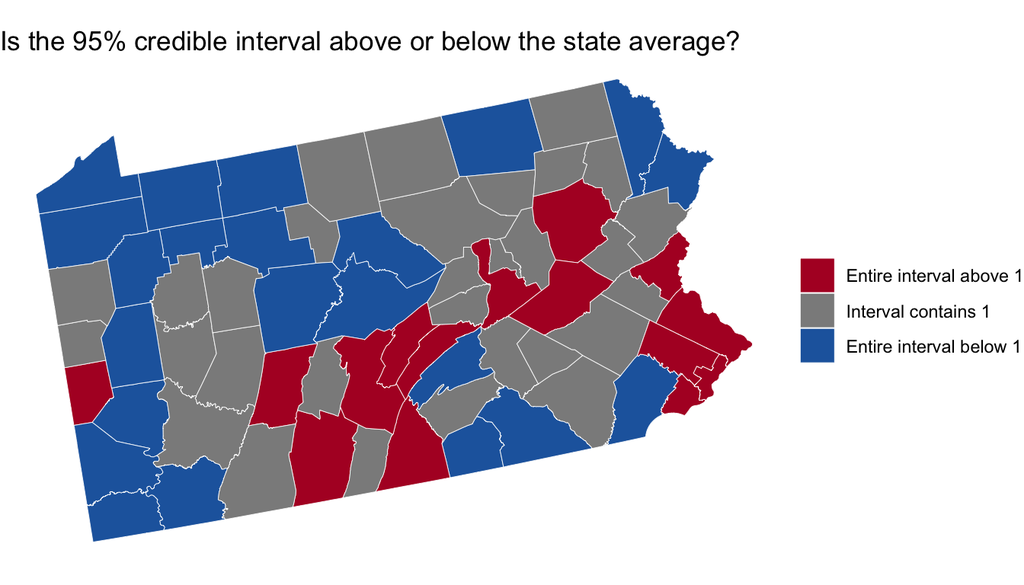

```r
ggplot(pa_covid) +
  geom_sf(aes(fill = ci_class), colour = "white", linewidth = 0.15) +
  scale_fill_manual(values = ci_cols, drop = FALSE, name = NULL) +
  labs(title = "Is the 95% credible interval above or below the state average?") +
  theme_void()
```

**F1.** In which parts of Pennsylvania are the red counties? Do the same parts stand out as in your SaTScan clusters of Exercise 6?

**The red counties are mostly scattered throughout the south central and eastern portion of Pennsylvania. Some parts are similar from exercise six, like in the southeast and central regions. Cambria, Bedford, and Franklin and Huntingdon, Mifflin, and Juniata are the same in the center portion. Northumberland, Schuylkill, Luzerne, as well as Northampton, Bucks, Montgomery, Delaware and Philadelphia in the southeast.**

## Part G — Wrapping up (1 point)

**G1.** In two or three sentences, for a county health officer: when would you show the raw SMR map, and when the INLA results (best guess and credible intervals)? End with one sentence on whether and how you used AI tools. **For a county health officer, the SMR map is helpful to show observed vs expected. I think using the INLA results is helpful to show the risk and how it differs across counties which could be good to know where to focus public health resources or interventions. It’s more helpful because the credible intervals can show the confidence that a county is below or above the state average.** **I didn’t use AI in this, just looked back at class notes**

## Points

| Part | What earns the points | Points |
| --- | --- | --- |
| A | The SMR map; one more death in a small county | 1 |
| B | Prior versus data, explained with $w$; a credible interval computed by hand | 3 |
| D | Two intervals read off; same SMR, different certainty; small versus large counties | 3 |
| E | Borrowing from the neighbours | 1 |
| F | Where the risk is clearly higher | 1 |
| G | When to show which map; AI use note | 1 |
|  | **Total (extra credit)** | **10** |

Clear, simple sentences are what earn the points; length does not.

## References

Moraga, P. (2019). *Geospatial health data: Modeling and visualization with R-INLA and Shiny*. Chapman & Hall/CRC, Ch. 3–5.

Riebler, A., Sørbye, S. H., Simpson, D., & Rue, H. (2016). An intuitive Bayesian spatial model for disease mapping that accounts for scaling. *Statistical Methods in Medical Research*, 25(4), 1145–1165.